# Distributions (Part I)

Bis335

## Contents

### Selected Model

- Uniform distribution: Discrete and Continuous Uniform distribution
- Bernoulli process related distribution: Bernoulli, Binomial, Hypergeometric, Negative binomial, Geometric distribution
- Poisson process related distribution: Poisson (discrete), Exponential, Gamma, Beta
- Normal distribution related: most of extra models below (Chapter 5)
  - Extra Models (for advanced students’ self study - Those will be included in quiz 3)
    - Chi-squared, T, F, Extreme value, Log-nomal, Cauchy, Weibull, Multinomial, Multivariate normal, Dirichlet distribution

### Special references for this chapter

- http://www.distributome.org/
- Hand-book on STATISTICAL DISTRIBUTIONS for experimentalists, Walck (4PDFtheoryFull.pdf)
- Handbook of statistical distribution with applications, Krishnamoorthy, 2006, Chapman & Hall/CRC
- Mathematical Statistics by Wackerly et al or any others.

## Tutorial

### Discrete Uniform Distribution (s5)

- tossing a fair die

```r
# install.packages("prob")
suppressMessages(library(prob))
fairdie <- rolldie(1, makespace = TRUE)
Ex <- sum(fairdie$X1*fairdie$probs)
Ex2 <- sum(fairdie$X1^2*fairdie$probs)
Var_x <- Ex2 - Ex^2
Var_x
```

```
## [1] 2.916667
```

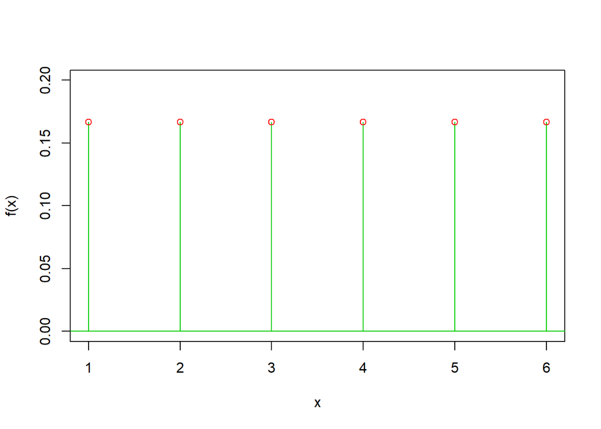

```r
pmf <- fairdie$probs
cdf <- cumsum(pmf)
cdf <- c(0,cdf)

# Plot the probability mass function (pmf)
plot(1:6, fairdie$probs, type = 'h', col = 3, ylim = c(0,0.2), xlab = 'x', ylab = 'f(x)')
points(1:6, fairdie$probs, col = 2)
abline(h = 0, col = 3)
```

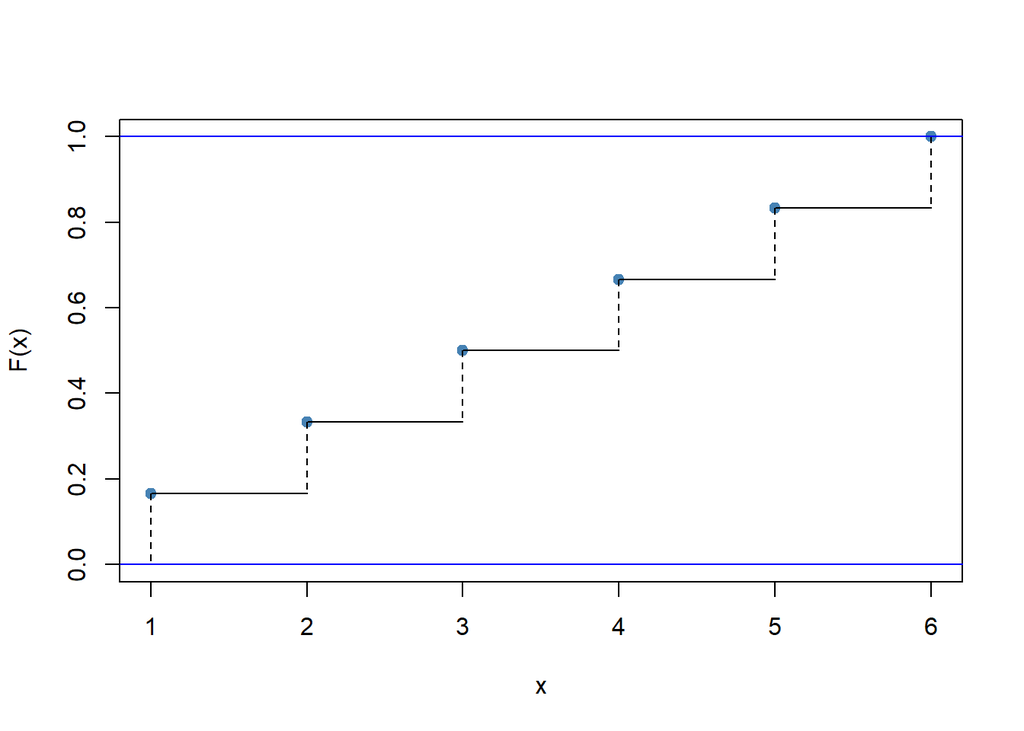

```r
# Plot the cumulative distribution function (cdf)
plot(1:6, cdf[2:length(cdf)], type = 'p', col = 'steelblue', ylim = c(0,1),
     pch = 19, xlab = 'x', ylab = 'F(x)')
segments(x0 = 0:6, x1 = 0:6 + 1, y0 = cdf)
segments(x0 = 0:6 + 1, y0 = c(cdf[-1], 1), y1 = cdf, lty = 2)
abline(h = 0:1, col = 4)
```

```r
# alternative approach
# sampling
rdu <- function(n,k) sample(1:k,n,replace = T)

table(rdu(100,6))/100
```

```
##
##    1    2    3    4    5    6
## 0.25 0.15 0.19 0.10 0.18 0.13
```

```r
table(rdu(1000,6))/1000
```

```
##
##     1     2     3     4     5     6
## 0.183 0.140 0.171 0.181 0.173 0.152
```

```r
table(rdu(10000,6))/10000
```

```
##
##      1      2      3      4      5      6
## 0.1667 0.1698 0.1669 0.1587 0.1666 0.1713
```

```r
# pmf
pmf <- function(x,k) ifelse(x >= 1 & x <= k & round(x) == x,1/k,0)
pmf(1:6,6)
```

```
## [1] 0.1666667 0.1666667 0.1666667 0.1666667 0.1666667 0.1666667
```

```r
# cdf
cdf <- function(x,k) ifelse(x < 1,0,ifelse(x <= k,floor(x)/k,1))
cdf(1:6, 6)
```

```
## [1] 0.1666667 0.3333333 0.5000000 0.6666667 0.8333333 1.0000000
```

### Continuous uniform distribution (s7)

Suppose that each oyster contains a pearl with a diameter in mm that has a $U(0,10)$ distribution. Get the expected pearl diamter, variance standard deviation, the probability that the diameter is larger than 3 mm.

```r
a <- 0
b <- 10
x <- 3

# the expected pearl diameter and variance, standard deviation
Ex <- (a + b) / 2
Var <- (b - a)^2 / 12
SD <- sqrt(Var)
Ex; Var; SD
```

```
## [1] 5
```

```
## [1] 8.333333
```

```
## [1] 2.886751
```

```r
# the probability that the diameter is larger than 3mm
1 - punif(x, min = a, max = b)
```

```
## [1] 0.7
```

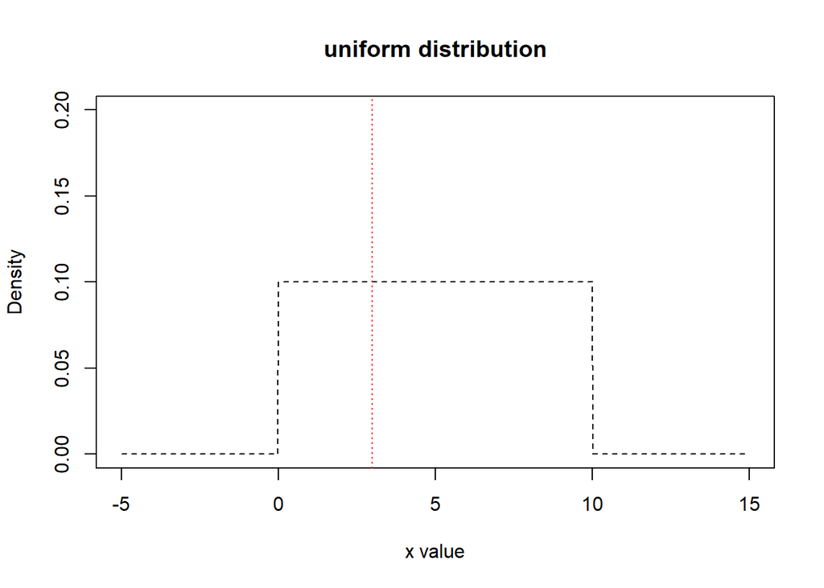

```r
x <- seq(-5, 15, length = 1000)
hx <- dunif(x, min = a, max = b)
plot(x, hx, type = "l", lty = 2, xlab = "x value", ylim = c(0,0.2),
     ylab = "Density", main = "uniform distribution")
abline(v = 3, lty = 3, col = "red")
```

### Continuous uniform distribution - Semiconservative replication (s7)

Suppose semiconservative replication occurs every half hour in an organism. What is the probability that the scientist will have to wait at least 20 minutes to observe the semiconservative replication? assume semiconservative replication follows uniform distribution $U(0,30)$. In other words, the semiconservative replication could equally occur any time between 0 to 30 min. calculate probability of the event occur after 20 min.

```r
a <- 0
b <- 30

# P(X>=20) = 1-P(X<20)
1 - punif(20, min = a, max = b)
```

```
## [1] 0.3333333
```

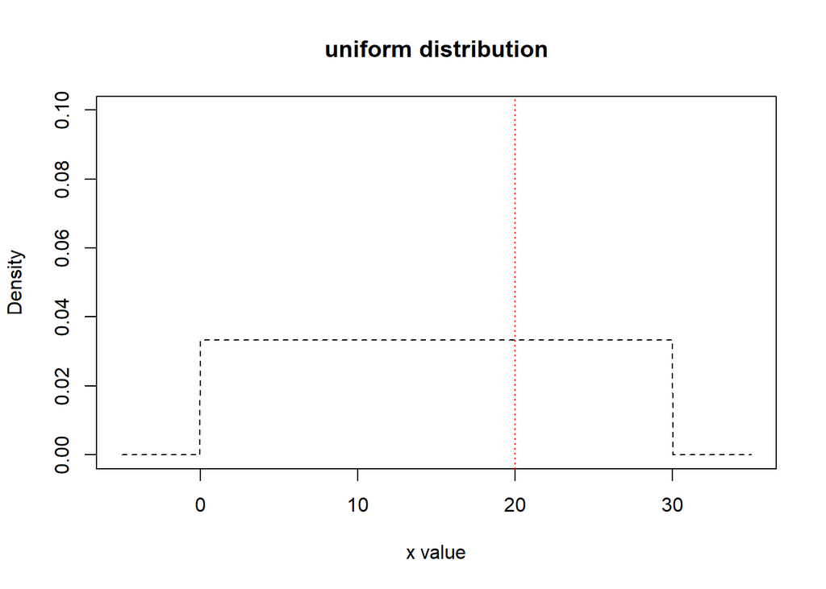

```r
x <- seq(-5, 35, length = 1000)
hx <- dunif(x, min = a, max = b)
plot(x, hx, type = "l", lty = 2, xlab = "x value", ylim = c(0,0.1),
     ylab = "Density", main = "uniform distribution")
abline(v = 20, lty = 3, col = "red")
```